# Time Series Analysis

Unemployment in the UK

Karisha Vekaria

March 2024

As part of my project I have conducted a time series analysis of unemployment in the UK. The data I have sampled aims to:

- Uncover trends
- Establish patterns
- Predict future behaviour through forecasting

Unemployment in the Uk is measured by the Labour Force Survey, which calculates the number of people who are without a job and are seeking employment or those who are transitioning between jobs. The data I have used in my analysis is extracted from the published results of the LFS, posted on the Office for National Statistics website.(https://www.ons.gov.uk/employmentandlabourmarket/peoplenotinwork/unemployment/timeseries/mgsx/lms)

In particular, my analysis uses the ‘unemployment rate’, which is a calculation of the number of unemployed people divided by the economically active population. This allows us to interpret this data in a wider context by taking into consideration different factors such as changes in population.

My data set covers the time period 1971 to 2023 and contains the monthly unemployment rates of each respective year.

Below is the code that I have used to introduced my data into this time series analysis, through the use of Meta’s forecasting system- ‘Prophet’.

```r
unemployment.df<- read.csv('Own cw/Unemployment DS.csv')

unemployment.df= data.frame(
  ds= zoo::as.yearmon(unemployment.df$Year, format= "%Y"),
  y= unemployment.df$Unemployment.Rate)


m = prophet::prophet(unemployment.df)
```

```
## Disabling weekly seasonality. Run prophet with weekly.seasonality=TRUE to override this.
```

```
## Disabling daily seasonality. Run prophet with daily.seasonality=TRUE to override this.
```

```r
future = prophet::make_future_dataframe(m, periods=10, freq="year")
forecast = predict(m, future)
```

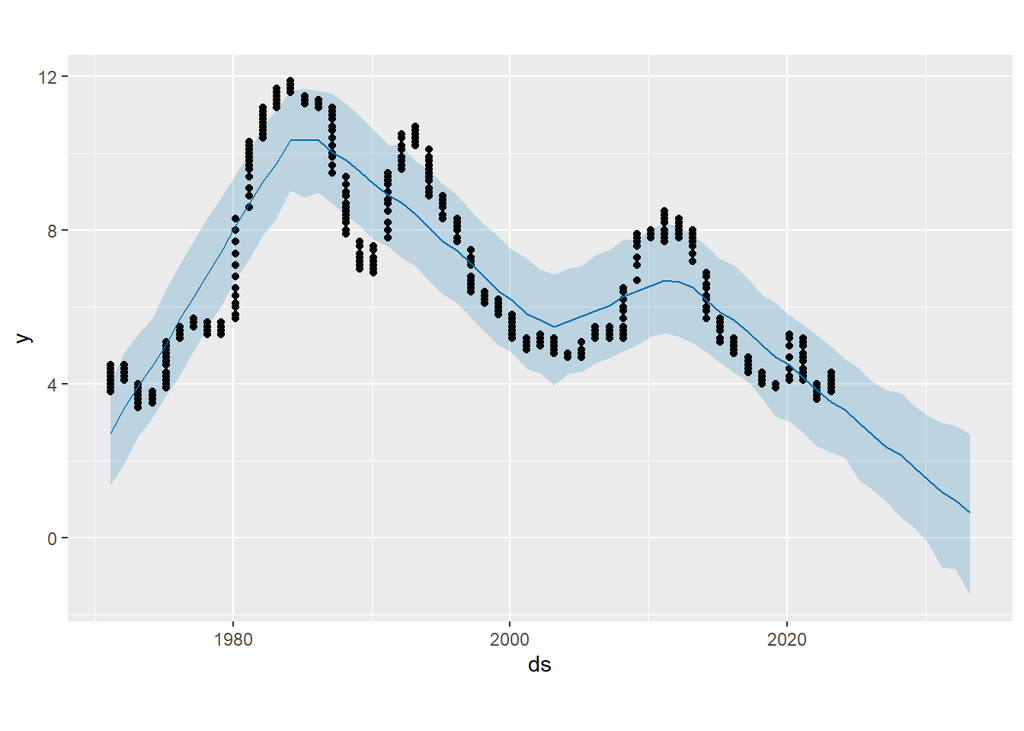

```r
plot(m,forecast)
```

**Figure 1** above illustrates unemployment through time, using historic data to provide predictions for future unemployment rates.

```r
prophet::dyplot.prophet(m, forecast)
```

[interactive chart not shown]

**Figure 2** above is an interactive model of figure 1 which can be used to get more precise readings.

The code below uses the prophet library to generate a forecast using the historic data provided. Below are some visualisations of the components making up the prophet forecast.

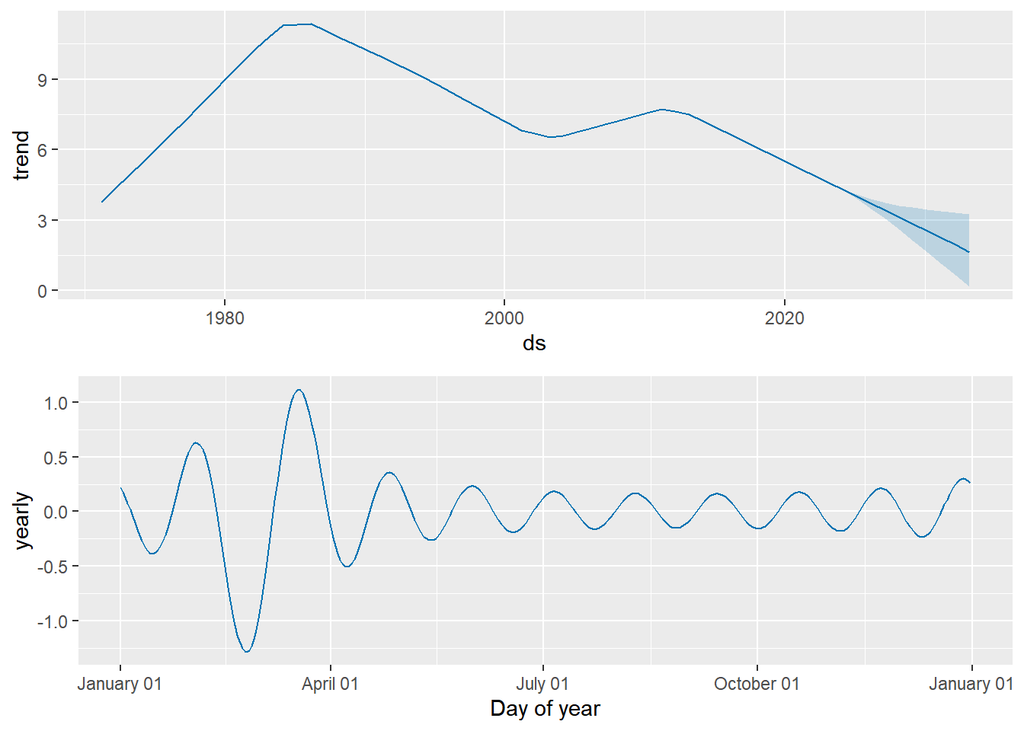

```r
prophet::prophet_plot_components(m, forecast)
```

**Figure 3.1 and 3.2** respectively

**Figure 3.1** above is a plot of time against trend. Trend refers to a long-term underlying pattern of evolution in the data. Overall, there is a gradual downward trend in unemployment over time. We can see in particalur that unemployment was at an all time high around 1985. It is important to consider, there may also have been external factors influencing these changes. For instance, in this time period, the UK was facing a global recession, and deindustrialisation and de-unionisation policies being employed by the new Conservative government - this combination of events led to rising unemployment. An economic boom later in the decade helped bring unemployment down again. After the 2008 financial crisis, we can see unemployment rates begin to rise once more. This plot captures long-term trends so it should be considered that the effects of seasonal changes and holidays are not seen in this plot.

Overall, this time series analysis of UK unemployment rates revealed there is downward trend in the rates observed and these rates forecast to continue to decline, possibly to the lowest rate in 60 years. However, it must be noted that the historical data doesn’t take into consideration, recent technological advancements (particularly in Artificial Intelligence(AI)) which can have a significant impact on job trends and therefore, unemployment. We have slowly begun to see certain industries being impacted by the rise of AI and it must be noted that there will be a time-lag before these effects will be seen in employment data. To make this analysis more sophisticated, we can further break down unemployment figures and split them by factors such as gender, age and migration. By doing so, we may be able to unveil different contributing factors to unemployment which would otherwise not be considered. For example, if there was a rise in birth rates in a particular year, we would likely see a significant rise in unemployment amongst women. Similarly, an aging population would result in more people leaving the workforce and again a rise in unemployment rates. Increased migration would also likely see unemployment rise as the percentage of people willing and able to work falls. Therefore, whilst the forecast shows good baseline predictions, the consideration of other external factors would provide a more accurate forecast for future unemployment rates. These findings highlight the importance of continuous monitoring of the labour market. They help us understand the seasonal fluctuations, underlying trends and the influence of external factors in unemployment. This can assist policy makers in developing effective methods to boost the labour market and promote job creation, in turn improving the overall economic well being of the UK.